# MSDS 6306 Assignment 09: Web Scrapping

J Lancon

November 6, 2017

### Assignment: Unit 09 Assignment

#### Course: MSDS 6306 - 405 Doing Data Science

#### Project Description: Web Scrapping

##### GitHub Repository: https://github.com/jlancon/MSDS6306/tree/master/Homework/Unit_9

**Problem #1:** Navigate to IMDB website and find the movie [Harry Potter and the Deathly Hallows: Part 2](http://www.imdb.com/title/tt1201607/fullcredits?ref_=tt_ql_1). Scrape the page with any R package you are comfortable with. We are interested is the table of the Cast in order of crediting.

- Parse down the table to only include the Actor’s Name and their corresponding Character in the movie.
- Clean observation; eliminating empty fields and fields with improper data.
- One Actor plays two characters, whos character name(s) has special() characters in its description. Replace his character name, removing special characters, so it displays properly.
- The Actor variable includes first name and surname. Split the variable into FirstName and Surname. Play special attention to multiple names/middle names, etc.
- Display the first 10 rows of the ‘cleaned’ dataframe with 3 variables (FirstName, Surname, Character)

##### Reading Website / Scrapping Data

**Reading website** into R Website Address for movie: http://www.imdb.com/title/tt1201607/fullcredits?ref_=tt_ql_1

```r
URLMovie <- read_html("http://www.imdb.com/title/tt1201607/fullcredits?ref_=tt_ql_1")
```

**Scrapping Table** with Actor & Character information

```r
# From YouTube video https://www.youtube.com/watch?v=gSbuwYdNYLM
Table_Data <- URLMovie %>%
      html_nodes('table') %>% .[[3]] %>%
      html_table()
```

**Parsing Table** to only include Actor’s Full Name and corresponding Character in movie.

```r
Actor_Character.df <- Table_Data[,c(2,4)]
colnames(Actor_Character.df) <- c("ActorFullName","Character")
```

**Cleaning erroneous observations** and modifying Character observation for Actor who plays multiple roles(eliminating special character(s))

```r
Actor_Character.df <- Actor_Character.df[- grep("Rest of cast listed",Actor_Character.df$ActorFullName),]
Actor_Character.df <- Actor_Character.df[!apply(Actor_Character.df == "",1,all),]
Character.df <- as.data.frame(sapply(Actor_Character.df[,2],gsub,pattern=".*Grip.*",replacement="Griphook / Professor Filius Flitwick"))
```

**Splitting Actor Name Field** into First Name and Surname, using technique that will leave Middle names and/or multiple first names in First Name field.

```r
First_Surname.df <- as.data.frame(str_split_fixed(Actor_Character.df$ActorFullName, ' (?=[^ ]+$)',2))
#Alternate Solution
#First_Surname.df <- as.data.frame(do.call(rbind, strsplit(Actor_Character_Data$Actor, ' (?=[^ ]+$)', perl=TRUE)))
```

**Combining Dataframes** into Cleaned Dataset for use in future analysis.  
**Displaying Table** for reference. Only displaying first 10 observations.

```r
FinalList.df <- cbind(First_Surname.df,Character.df)
colnames(FinalList.df) <- c("FirstName", "Surname", "Character")

kable(head(FinalList.df,10), align="c", caption="Harry Potter and the Deathly Hallows: Part 2 Cast and Character",format="markdown",row.names = FALSE)
```

**Harry Potter and the Deathly Hallows Part 2: Cast and Characters**

| FirstName | Surname | Character |
| --- | --- | --- |
| Ralph | Fiennes | Lord Voldemort |
| Michael | Gambon | Professor Albus Dumbledore |
| Alan | Rickman | Professor Severus Snape |
| Daniel | Radcliffe | Harry Potter |
| Rupert | Grint | Ron Weasley |
| Emma | Watson | Hermione Granger |
| Evanna | Lynch | Luna Lovegood |
| Domhnall | Gleeson | Bill Weasley |
| Clémence | Poésy | Fleur Delacour |
| Warwick | Davis | Griphook / Professor Filius Flitwick |

**Problem #2:** Navigate to ESPN website, there are statistics of each NBA player, and find the [San Antonio Spurs stats webpage](http://www.espn.com/nba/team/stats/_/name/sa/san-antonio-spurs); which displays player’s current statistics.

- Interested in **Shooting Statistics** table.
- Parse down the table to only include the Player’s Name and Field Goal Percentage (FG%).
- Clean observation; eliminating empty fields and fields with improper data.
- One Actor plays two characters, whos character name(s) has special() characters in its description. Replace his character name, removing special characters, so it displays properly.
- The Player catagory includes the Full Name of player as well as position. Split the variable into Player Name and Position.
- Create a ‘cleaned’ dataset with Player’s Name, Position, and Field Goal Percentage
- Create a bar graph displaying Player and their FG%. Color the columns by the Player’s position.

##### Reading Website / Scrapping Data

**Reading website** into R Website Address for Team stats: http://www.espn.com/nba/team/stats/_/name/sa/san-antonio-spurs

```r
URLSpurs <- read_html('http://www.espn.com/nba/team/stats/_/name/sa/san-antonio-spurs')
```

**Scrapping Table** with Player and Statistics information

```r
Table_Data_Spurs <- URLSpurs %>%
  html_nodes('table') %>% .[[2]] %>%
  html_table()
```

**Parsing Table** to only include Player’s Name and FG% statistics.

```r
Player_FGP.df <- Table_Data_Spurs[,c(1,4)]
```

**Cleaning Erroneous Observations**

```r
Player_FGP.df <- Player_FGP.df[- grep("Totals",Player_FGP.df$X1),]
Player_FGP.df <- Player_FGP.df[- grep("SHOOTING STATISTICS",Player_FGP.df$X1),]
Player_FGP.df <- Player_FGP.df[- grep("PLAYER",Player_FGP.df$X1),]
```

**Extracting Variable and Changing Data Class** of FG% from Character to Numeric.

```r
FGPercent.df <- as.data.frame(as.numeric(Player_FGP.df$X4))
```

**Splitting Player’s Name Variable** into Player’s Name and Position. Eliminate unnecessary characters “,” in variable observations.

```r
Player_Position.df <- as.data.frame(str_split_fixed(Player_FGP.df$X1, ' (?=[^ ]+$)',2))
Player_Position.df <- as.data.frame(sapply(Player_Position.df,gsub,pattern=",",replacement=""))
```

**Combining Dataframes** into Cleaned Dataset with Player’s Name, Position, and FG%.

```r
Final.df <- cbind(Player_Position.df,FGPercent.df)
colnames(Final.df) <- c("Player", "Position", "FG_Percent")
Final.df <- Final.df[order(Final.df$FG_Percent, decreasing = TRUE), ]
```

**SA Spurs Bar Graph** displaying Player’s current Field Goal Percentages for 2017/18 season.

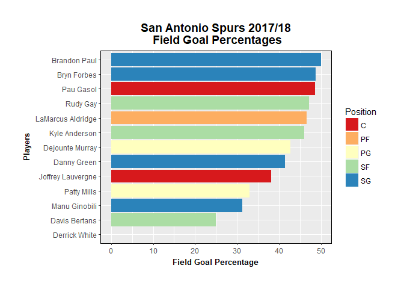

```r
ggplot(data=Final.df, aes(x=reorder(Player, order(Final.df$FG_Percent, decreasing=FALSE)),y=(FG_Percent*100),fill=Position)) +
  geom_bar(position="dodge",stat="identity") +
  scale_fill_brewer(palette="Spectral") +
#  scale_fill_hue(c=80, l=60) +
  coord_flip() +
  xlab("Players") +
  ylab("Field Goal Percentage") +
  ggtitle("San Antonio Spurs 2017/18\n Field Goal Percentages") +
  theme(plot.title = element_text(hjust = 0.5, face="bold", size=14)) +
  theme(axis.title = element_text(face="bold", size=10)) +
  theme(axis.title.y = element_text(face="bold", size=10)) +
  theme(panel.border = element_rect(linetype = "solid", fill = NA)) +
  theme(plot.margin = unit(c(1,1,1,1), "cm"))
```